# PEB advanced R workshop

GIovanni M DallOlio

19/04/2015

Welcome to the PEB advanced R workshop!

## Requirements

Let’s install all the required packages:

```r
pkgs = c("tidyr", "dplyr", "ggplot2", "reshape2")
#for (pkg in pkgs) install.packages(pkg)
for (pkg in pkgs) library(pkg, character.only=T)
```

The tidyr package requires at least R 3.1.2. If you can’t install it, you can use reshape2 instead, but you won’t be able to follow some of the exercises.

We also need to download the following **data files**:

```r
#download.file('https://raw.githubusercontent.com/dalloliogm/peb_workshop/master/peb_expression.csv', dest='peb_expression.csv')
#download.file('https://raw.githubusercontent.com/dalloliogm/peb_workshop/master/cancer_genes.csv', dest='cancer_genes.csv')
```

## the peb_expression.csv file

Let’s read the peb_expression.csv file that we just downloaded, and have a look at its contents.

```r
peb = read.table("peb_expression.csv", header=T, sep='\t')
head(peb)
```

```
##        ID_REF IDENTIFIER GSM11815.YRI GSM11832.YRI GSM12069.YRI
## 1 200000_s_at      PRPF8       4254.0       5298.2       4026.5
## 2   200001_at     CAPNS1      17996.2      12010.7      10283.5
## 3   200002_at      RPL35      41678.8      39116.9      38758.9
## 4 200003_s_at      RPL28      65390.9      34806.2      31257.2
## 5   200004_at     EIF4G2      19030.1      15813.6      16355.7
## 6   200005_at      EIF3D       8824.5       9706.2      10590.0
##   GSM12083.YRI GSM12101.YRI GSM12106.EUR GSM12274.EUR GSM12299.EUR
## 1       3498.4       3566.4       4903.1       6372.6       4829.1
## 2       2534.7      11048.4      13354.0       8563.8      17247.6
## 3      32847.7      39633.9      43511.2      46856.7      47032.4
## 4      28308.5      67447.5      56989.9      57972.5      57570.5
## 5       9579.7      14273.5      17217.0      19116.9      17487.6
## 6       6986.7       9400.4      12835.2      10299.0      12375.2
##   GSM12412.EUR GSM11810.EUR GSM11827.EUR GSM12078.EAS GSM12099.EAS
## 1       5205.8       2756.8       3932.0       3729.9       3223.4
## 2      16018.5       6077.0      15703.8      10138.5      11614.4
## 3      22152.2      26660.7      26373.6      23809.6      24749.3
## 4      29062.2      35140.9      23629.3      22100.5      21651.0
## 5      14671.6      17733.1      18022.4      17957.4      15958.0
## 6       7645.4       8661.5       7355.7       6973.4       6855.9
##   GSM12269.EAS GSM12287.EAS GSM12301.EAS GSM12448.EAS
## 1       3640.5       4886.3       4070.2       3482.1
## 2       8460.5      10282.6      11844.3       9741.6
## 3      21936.8      31462.8      22733.7      25395.5
## 4      18550.7      23496.5      21315.4      28631.4
## 5      15799.8      16685.8      18817.3      17421.1
## 6       7949.2       9486.5       7494.5       7252.1
```

```r
summary(peb)
```

```
##          ID_REF          IDENTIFIER     GSM11815.YRI
##  200000_s_at:    1   --Control:   68   Min.   :     0.3
##  200001_at  :    1   AF137396 :   10   1st Qu.:    89.5
##  200002_at  :    1   ZDHHC21  :    9   Median :   265.6
##  200003_s_at:    1   AE000660 :    8   Mean   :   750.8
##  200004_at  :    1   C6orf12  :    8   3rd Qu.:   619.6
##  200005_at  :    1   NAV1     :    8   Max.   :102611.9
##  (Other)    :22639   (Other)  :22534
##   GSM11832.YRI      GSM12069.YRI      GSM12083.YRI       GSM12101.YRI
##  Min.   :    0.8   Min.   :    0.6   Min.   :     3.6   Min.   :     2.6
##  1st Qu.:   82.5   1st Qu.:   73.0   1st Qu.:   112.8   1st Qu.:   113.0
##  Median :  250.3   Median :  218.5   Median :   309.7   Median :   281.9
##  Mean   :  742.4   Mean   :  747.8   Mean   :   735.2   Mean   :   803.1
##  3rd Qu.:  601.1   3rd Qu.:  574.0   3rd Qu.:   650.4   3rd Qu.:   627.1
##  Max.   :92709.0   Max.   :77751.6   Max.   :163393.7   Max.   :138396.3
##
##   GSM12106.EUR      GSM12274.EUR       GSM12299.EUR       GSM12412.EUR
##  Min.   :    0.6   Min.   :     1.1   Min.   :     0.7   Min.   :    1.2
##  1st Qu.:   81.2   1st Qu.:    96.0   1st Qu.:    68.1   1st Qu.:   92.5
##  Median :  240.1   Median :   280.2   Median :   217.0   Median :  264.4
##  Mean   :  744.1   Mean   :   760.8   Mean   :   801.8   Mean   :  685.4
##  3rd Qu.:  600.2   3rd Qu.:   642.0   3rd Qu.:   555.7   3rd Qu.:  622.9
##  Max.   :75119.9   Max.   :184913.3   Max.   :106337.6   Max.   :72757.5
##
##   GSM11810.EUR       GSM11827.EUR       GSM12078.EAS
##  Min.   :     2.1   Min.   :     1.0   Min.   :     1.8
##  1st Qu.:    88.0   1st Qu.:    86.5   1st Qu.:    87.1
##  Median :   273.8   Median :   264.6   Median :   266.5
##  Mean   :   765.1   Mean   :   780.1   Mean   :   774.4
##  3rd Qu.:   623.1   3rd Qu.:   614.3   3rd Qu.:   615.0
##  Max.   :181955.8   Max.   :177591.8   Max.   :165359.5
##
##   GSM12099.EAS       GSM12269.EAS       GSM12287.EAS
##  Min.   :     0.6   Min.   :     1.8   Min.   :     0.4
##  1st Qu.:    89.2   1st Qu.:   125.9   1st Qu.:    76.7
##  Median :   269.3   Median :   288.6   Median :   238.7
##  Mean   :   765.9   Mean   :   710.3   Mean   :   791.5
##  3rd Qu.:   606.6   3rd Qu.:   632.3   3rd Qu.:   582.5
##  Max.   :149856.8   Max.   :107443.7   Max.   :159424.0
##
##   GSM12301.EAS       GSM12448.EAS
##  Min.   :     1.1   Min.   :     0.7
##  1st Qu.:    80.1   1st Qu.:    84.0
##  Median :   244.5   Median :   264.3
##  Mean   :   769.9   Mean   :   757.1
##  3rd Qu.:   582.2   3rd Qu.:   615.9
##  Max.   :106539.3   Max.   :131802.0
##
```

The first two columns contain the probe ID and the name of the gene. The other columns contain the expression levels of each gene in an individual. Notice how the name of the columns also encode the population of each individual, e.g. YRI, EUR, or EAS.

## A piping system for R

The dplyr package introduced a piping system for R, using the %>% symbol.

This works similarly to the | in bash. We first write the name of the dataframe to use, then all the operation that must be executed on it.

For example, the following is equivalent to head(peb)

```r
peb %>% head
```

```
##        ID_REF IDENTIFIER GSM11815.YRI GSM11832.YRI GSM12069.YRI
## 1 200000_s_at      PRPF8       4254.0       5298.2       4026.5
## 2   200001_at     CAPNS1      17996.2      12010.7      10283.5
## 3   200002_at      RPL35      41678.8      39116.9      38758.9
## 4 200003_s_at      RPL28      65390.9      34806.2      31257.2
## 5   200004_at     EIF4G2      19030.1      15813.6      16355.7
## 6   200005_at      EIF3D       8824.5       9706.2      10590.0
##   GSM12083.YRI GSM12101.YRI GSM12106.EUR GSM12274.EUR GSM12299.EUR
## 1       3498.4       3566.4       4903.1       6372.6       4829.1
## 2       2534.7      11048.4      13354.0       8563.8      17247.6
## 3      32847.7      39633.9      43511.2      46856.7      47032.4
## 4      28308.5      67447.5      56989.9      57972.5      57570.5
## 5       9579.7      14273.5      17217.0      19116.9      17487.6
## 6       6986.7       9400.4      12835.2      10299.0      12375.2
##   GSM12412.EUR GSM11810.EUR GSM11827.EUR GSM12078.EAS GSM12099.EAS
## 1       5205.8       2756.8       3932.0       3729.9       3223.4
## 2      16018.5       6077.0      15703.8      10138.5      11614.4
## 3      22152.2      26660.7      26373.6      23809.6      24749.3
## 4      29062.2      35140.9      23629.3      22100.5      21651.0
## 5      14671.6      17733.1      18022.4      17957.4      15958.0
## 6       7645.4       8661.5       7355.7       6973.4       6855.9
##   GSM12269.EAS GSM12287.EAS GSM12301.EAS GSM12448.EAS
## 1       3640.5       4886.3       4070.2       3482.1
## 2       8460.5      10282.6      11844.3       9741.6
## 3      21936.8      31462.8      22733.7      25395.5
## 4      18550.7      23496.5      21315.4      28631.4
## 5      15799.8      16685.8      18817.3      17421.1
## 6       7949.2       9486.5       7494.5       7252.1
```

## Converting to a long format

All the functions used in the rest of the workshop require the dataset to be in a long format. Let’s convert it using the gather() function from tidyr:

```r
peb.long = gather(peb, sample, expression, -ID_REF, -IDENTIFIER)
head(peb.long)
```

```
##        ID_REF IDENTIFIER       sample expression
## 1 200000_s_at      PRPF8 GSM11815.YRI     4254.0
## 2   200001_at     CAPNS1 GSM11815.YRI    17996.2
## 3   200002_at      RPL35 GSM11815.YRI    41678.8
## 4 200003_s_at      RPL28 GSM11815.YRI    65390.9
## 5   200004_at     EIF4G2 GSM11815.YRI    19030.1
## 6   200005_at      EIF3D GSM11815.YRI     8824.5
```

Explanation:

- sample is the name of the new column containing the key variables
- expression is the new column containing the values variable
- we use the - operator to define which columns must not be converted to the long format

Note how the new format has only four columns.

If you couldn’t install the tidyr package, you can achieve the same format using the *melt* function from reshape2

```r
peb.long = melt(peb, id.vars=c("ID_REF", "IDENTIFIER"), variable.name="sample")
names(peb.long)[4] = "expression"
head(peb.long, 3)
```

```
##        ID_REF IDENTIFIER       sample expression
## 1 200000_s_at      PRPF8 GSM11815.YRI     4254.0
## 2   200001_at     CAPNS1 GSM11815.YRI    17996.2
## 3   200002_at      RPL35 GSM11815.YRI    41678.8
```

## Tidying-up the peb.long dataframe

In a properly structured table each variable must contain only one type of information. If we look at our peb.long dataframe, the sample column contains both the individual ID and its population. Let’s split this column into two using *separate* from tidyr:

```r
peb.long.tmp = gather(peb, sample, expression, -ID_REF, -IDENTIFIER)
peb.long     = separate(peb.long.tmp, sample, into=c("individual", "population"), sep='\\.')
```

The above code can be simplified using the %>% operator:

```r
peb.long = peb %>%
  gather(sample, expression, -ID_REF, -IDENTIFIER) %>%
  separate(sample, into=c("individual", "population"), sep='\\.')
```

To prepare the dataset for our workshop, we need to apply a few more data filtering steps, like removing all the “Control” rows, eliminating all the duplicated genes (keeping only one probe per gene), and dropping the ID_REF column.

```r
peb.long %>% nrow
```

```
## [1] 384965
```

```r
peb.long = peb %>%
  gather(sample, expression, -ID_REF, -IDENTIFIER) %>%
  separate(sample, into=c("individual", "population"), sep='\\.') %>%
  subset(!grepl("Control", IDENTIFIER)) %>%
  subset(!duplicated(paste(IDENTIFIER, individual))) %>%
  select(-ID_REF)

peb.long %>% nrow
```

```
## [1] 305184
```

## Group operations

Apart from the %>% operator, the dplyr library introduces three useful functions: group_by, summarise and mutate.

- *group_by* is used to define how the rows of a dataset must be grouped. For example, we can group the rows of peb.long by population.
- *summarise* is used to calculate summaries of a grouped dataset - for example we can use it to calculate the mean and standard deviation of the expression for every population:

```r
peb.means = peb.long %>%
  group_by(population) %>%
  summarise(
    mean=mean(expression),
    sd=sd(expression))

peb.means %>% print
```

```
## Source: local data frame [3 x 3]
##
##   population     mean       sd
## 1        EAS 747.4846 2696.084
## 2        EUR 742.9541 2818.128
## 3        YRI 744.1489 2856.510
```

- *mutate* is used to add columns to a data frame. For example we can use it to check if a given gene is over or under expressed in an individual, compared to the other genes:

```r
peb.long = peb.long %>%
  group_by(individual) %>%
  mutate(
    mean.expression=mean(expression),
    overexpressed = ifelse(expression > mean.expression, "overexpressed", "underexpressed")
  )

peb.long %>% head %>% print.data.frame(row.names=F)
```

```
##  IDENTIFIER individual population expression mean.expression overexpressed
##       PRPF8   GSM11815        YRI     4254.0        736.6556 overexpressed
##      CAPNS1   GSM11815        YRI    17996.2        736.6556 overexpressed
##       RPL35   GSM11815        YRI    41678.8        736.6556 overexpressed
##       RPL28   GSM11815        YRI    65390.9        736.6556 overexpressed
##      EIF4G2   GSM11815        YRI    19030.1        736.6556 overexpressed
##       EIF3D   GSM11815        YRI     8824.5        736.6556 overexpressed
```

## Plotting the dataset

We will use the ggplot2 package to plot our peb.long dataframe.

A ggplot2 plot is composed by a base ggplot() object, defining the dataset and the basic variables used, and by additional elements defining how to represent them. Let’s see an example:

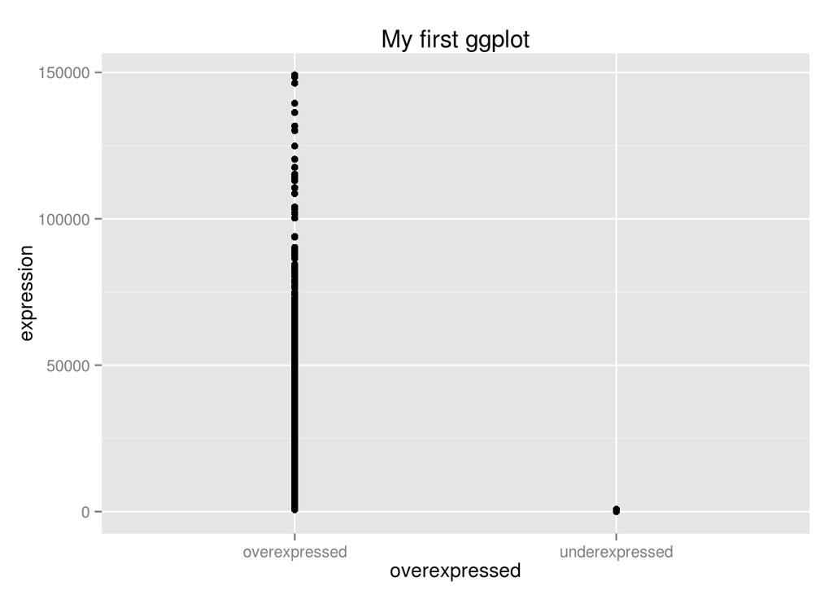

```r
ggplot(peb.long, aes(x=overexpressed, y=expression)) +
  geom_point() +
  ggtitle("My first ggplot")
```

Explanation:

- *ggplot(peb.long, aes(x=overexpressed, y=expression))* initialize the base ggplot2 object. We use the aes (for aesthetic) function to define the default x and y variables
- *geom_point* adds a scatterplot representation of the base plot
- *ggtitle* is another element of the plot, in this case the title.

Let’ try a boxplot representation:

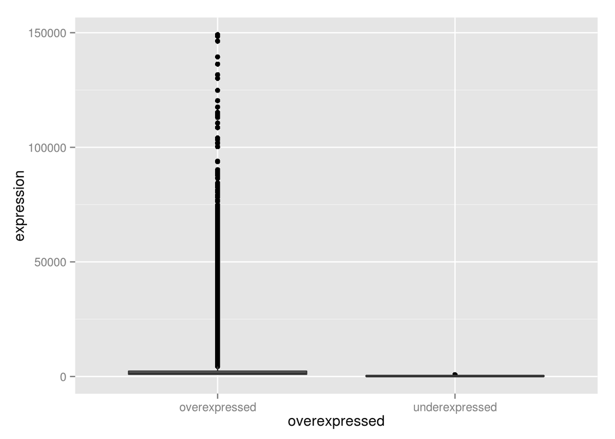

```r
ggplot(peb.long, aes(x=overexpressed, y=expression)) +
  geom_boxplot()
```

Let’s create a nicer plot, in which we color by the population variable, set limits for the Y axes, and use a whiter plot theme.

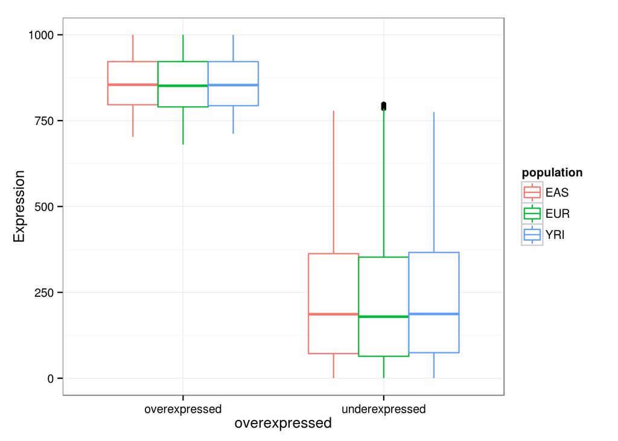

```r
ggplot(peb.long, aes(x=overexpressed, y=expression, color=population)) +
  geom_boxplot() +
  scale_y_continuous("Expression", limits=c(0, 1000)) +
  theme_bw()
```

## Classifying cancer genes

Remember that we also downloaded a file containing the classification of genes into oncogenes and tumor suppressors, from the NCG database:

```r
cancer = read.table("cancer_genes.csv", header=T)
cancer %>% head
```

```
##            dataset
## 1        oncogenes
## 2 tumorsuppressors
##                                                                                                                                                                                                                                                                                                          …
## 1 ABI1,CDH11,AKAP9,LHFP,CDK4,CDK6,OLIG2,GPHN,FSTL3,IKZF1,TFG,NDRG1,CDX2,NCOA2,CEBPA,SLC34A2,SEPT9,MALT1,MLLT11,CLP1,CNTRL,FGFR1OP,PSIP1,WIF1,CHN1,RMI2,LRIG3,CLTC,MSI2,CANT1,COL1A1,COX6C,CREB1,CREBBP,VTI1A,FLJ27352,CTNNB1,TTL,DDIT3,DDX5,DDX6,DDX10,ZNF384,EBF1,EGFR,EIF4A2,ELF4,ELK4,ELN,EPS15,ERBB2,…
## 2                                                                                                                                                                                                                                                                                                        …
```

This file doesn’t follow the principles of “tidy” data, according to which each row should represent only one single observation.

In this case we can use the unnest function from tidyr to convert it to a “long” format:

```r
cancer.long = cancer %>%
    mutate(genes=strsplit(as.character(genes), ",") ) %>%
    unnest(genes) %>%
    rename(IDENTIFIER=genes)

cancer.long %>% head
```

```
##     dataset IDENTIFIER
## 1 oncogenes       ABI1
## 2 oncogenes      CDH11
## 3 oncogenes      AKAP9
## 4 oncogenes       LHFP
## 5 oncogenes       CDK4
## 6 oncogenes       CDK6
```

Now we can use left_join from dplyr to add a column to our peb expression data frame:

```r
peb.long = peb.long %>%
    left_join(cancer.long, by='IDENTIFIER') %>%
    mutate(dataset = ifelse(is.na(dataset), "no-cancer", as.character(dataset)))
```

## advanced ggplot2

Now that we have more qualitative variables in peb.long, we can create more sophisticated plots. For example, an useful way to represent multi-dimensional data is facetting:

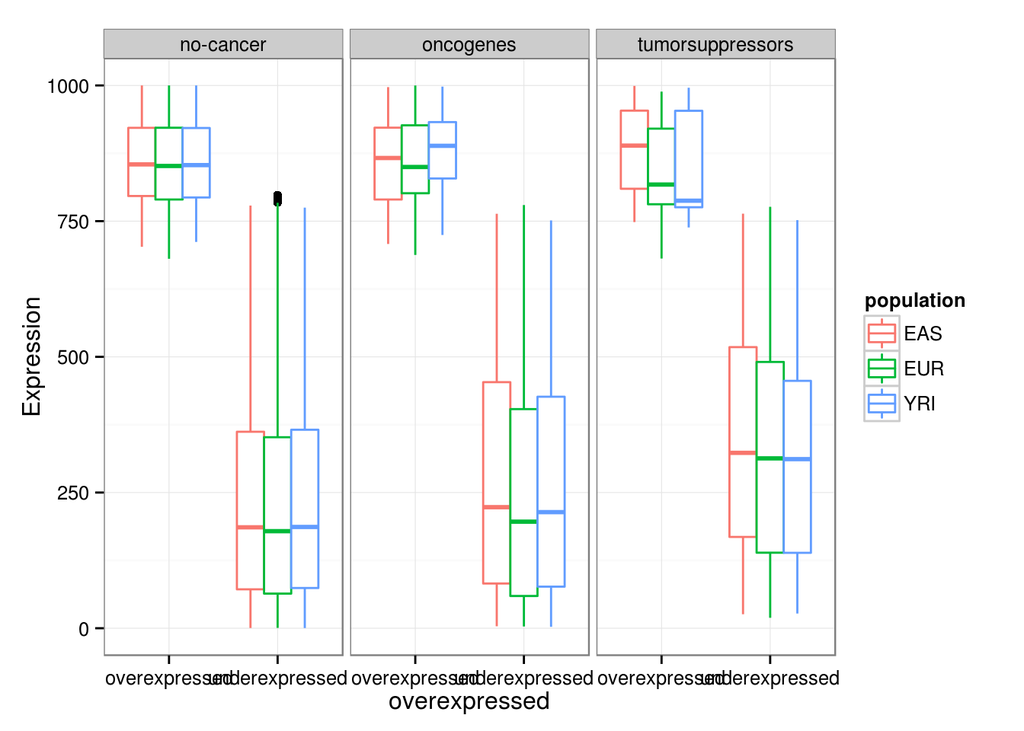

```r
ggplot(peb.long, aes(x=overexpressed, y=expression, color=population)) +
  facet_wrap(~dataset) +
  geom_boxplot() +
  scale_y_continuous("Expression", limits=c(0, 1000)) +
  theme_bw()
```